# Scikit

Scikit, c'est LA librairie la plus utilisée pour du machine learning de base. On va donc voir différentes fonctions pour faire des projets de machines learning et vous allez voir, ça n'est vraiment pas compliqué !

**Sommaire**

- 1. Scikit - Base
- 2. Prediction - Titanic
- 3. Résumé
- 4. Modèles de regression et erreurs
- 5. Pre-processing
- 6. Pipeline
- 7. Transformer - Feature selection
- 8. Apprentissage non-supervisé
- 9. Ensemble Learning

```python
from tools import find_file
```

Back to top

## 1. Scikit - Base

C'est simple, en gros, on prends des entrées $x_i$ et une sortie $y$ (un label), et le but est d'apprendre à un modèle à trouver $y$ suivant les $x_i$ donnés.

Pour l'apprentissage supervisé, on va avoir un jeu de données d'entrainement où l'on va pouvoir donner les $x_i$ au model et voir s'il est capable de trouver ou non le bon $y$, sachant que nous les connaitrons. Ensuite, on pourra avoir un jeu de test dont on connait aussi les $y$ mais que le modèle ne connait pas, pour voir s'il est suffisamment entrainé pour faire face à des données dont on ne connait pas la valeur $y$.

Bref, rien de bien méchant, notamment avec scikit !

### 1.1. Structure

Le fonctionnement est très simple :

1. On selectionne un modèle / estimateur et ses hyperparamètres

   > `model = LinearRegression()`
2. On entraine le modèle sur des données X et y (np.array)

   > `model.fit(X, y)`
3. On évalue le modèle

   > `model.score(X, y)`
4. On utilise le modèle quand il est suffisamment entrainé

   > `model.predict(X)`

Maintenant, à part les modèles qui peuvent changer et qu'il est important de connaitre et de comprendre, sinon le fonctionnement est toujours le même.

### 1.2. Modèles

Les modèles les plus intéressant sont :

- Les modèles linéaires :
  - `sklearn.linear_model.LinearRegression()`
  - `sklearn.linear_model.Ridge()`
  - `sklearn.linear_model.SGDRegressor()`
- Les modèles voisins :
  - `sklearn.neighbors.KNeighborsClassifier()`
- Les modèles support vector machine :
  - `sklearn.svm.SVC()`
  - `sklearn.svm.SVR()`

Pour plus d'infos :

[figure not shown]

### 1.3. Regression

```python
import numpy as np
import matplotlib.pyplot as plt

# Pour la regression :
from sklearn.linear_model import LinearRegression
```

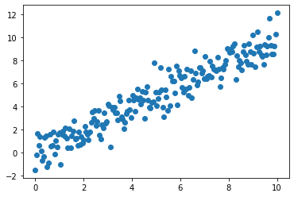

```python
sample = 200

X = np.linspace(0, 10, sample).reshape(sample, 1)
y = X + np.random.randn(sample, 1)

plt.scatter(X, y)
```

```python
model = LinearRegression()
model.fit(X, y)  # Entrainement
print(model.score(X, y))  # Coef de détermination pour évaluer le model
y_pred = model.predict(X)  # Prediction des mêmes données
```

```
0.9002343104817396
```

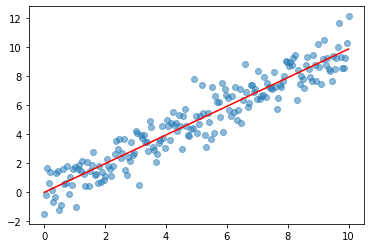

```python
# Maintenant on va prédire y :
plt.scatter(X, y, alpha=.5)
plt.plot(X, y_pred, c='r')
```

Not bad !

Testons avec d'autres données :

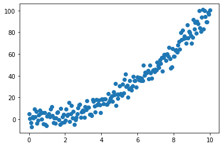

```python
X = np.linspace(0, 10, sample).reshape(sample, 1)
y = X**2 + np.random.randn(sample, 1)*5

plt.scatter(X, y)
```

```python
# Ici c'est pas linéaire, donc prenons un autre modèle :
from sklearn.svm import SVR
```

```python
# Même code que précédement, ou presque
model = SVR(C=100)
model.fit(X, y)  # Entrainement
print(model.score(X, y))  # Coef de détermination pour évaluer le model
y_pred = model.predict(X)
```

```
0.9711338259393535
```

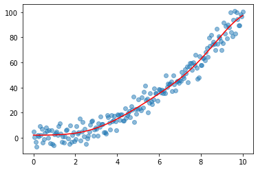

```python
# Maintenant on va prédire y :
plt.scatter(X, y, alpha=.5)
plt.plot(X, y_pred, c='r')
```

Back to top

## 2. Prediction - Titanic

### 2.1. Modèle de classification

```python
import pandas as pd
```

```python
# On réutilise le sample Titanic déjà vu dans la partie Pandas
titanic = pd.read_csv(find_file('titanic.csv'))[['survived', 'pclass', 'sex', 'age']]
titanic.dropna(axis=0, inplace=True)
titanic['sex'].replace(['male', 'female'], [0, 1], inplace=True)
titanic.head()
```

|  | survived | pclass | sex | age |
| --- | --- | --- | --- | --- |
| 0 | 1.0 | 1.0 | 1 | 29.0000 |
| 1 | 1.0 | 1.0 | 0 | 0.9167 |
| 2 | 0.0 | 1.0 | 1 | 2.0000 |
| 3 | 0.0 | 1.0 | 0 | 30.0000 |
| 4 | 0.0 | 1.0 | 1 | 25.0000 |

Cherchons si on peut deviner si un passager va survivre ou non suivant différentes données d'entrées. C'est donc un problème classification:

```python
from sklearn.neighbors import KNeighborsClassifier
```

```python
# On utilisera donc ce modèle
model = KNeighborsClassifier(n_neighbors=3)  # nombre de voisins à considérer
```

```python
# Divisons notre tableau
y = titanic.survived
X = titanic.drop('survived', axis=1)
X.head()
```

|  | pclass | sex | age |
| --- | --- | --- | --- |
| 0 | 1.0 | 1 | 29.0000 |
| 1 | 1.0 | 0 | 0.9167 |
| 2 | 1.0 | 1 | 2.0000 |
| 3 | 1.0 | 0 | 30.0000 |
| 4 | 1.0 | 1 | 25.0000 |

```python
model.fit(X, y)
model.score(X, y)
```

```
0.8384321223709369
```

Testons la prediction :

```python
model.predict(X)
```

```
array([1., 1., 1., ..., 0., 0., 0.])
```

```python
# Faisons une fonction pour prédire pour une personne données:
def survie(model, pclass=3, sex=0, age=25):
    # On fait un np.array avec les data dans le même ordre que le modèle entrainé
    x = np.array([pclass, sex, age]).reshape(1, 3)  # Pensons à reshape et éviter le (,3)

    return model.predict(x), model.predict_proba(x)

survie(model, 3, 0, 25)
```

```
(array([0.]), array([[1., 0.]]))
```

Cependant, là on test notre model sur les même données qu'il a vu pour s'entrainer. Normalement on split les données (80 / 20). Retestont ce que l'on a fait précédemment mais en splitant les données et utilisons les données d'Iris

### 2.2. Évaluer son modèle

```
(150, 4)
```

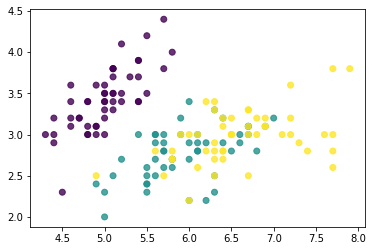

```python
from sklearn.datasets import load_iris

iris = load_iris()

X = iris.data
y = iris.target

print(X.shape)
plt.scatter(X[:, 0], X[:, 1], c=y, alpha=.8)
```

```python
# On va split avec une fonction intégrée
from sklearn.model_selection import train_test_split
```

```python
X_train, X_test, y_train, y_test = train_test_split(X, y, test_size=.2)

print('Train set :', X_train.shape)
print('Test set :', X_test.shape)
```

```
Train set : (120, 4)
Test set : (30, 4)
```

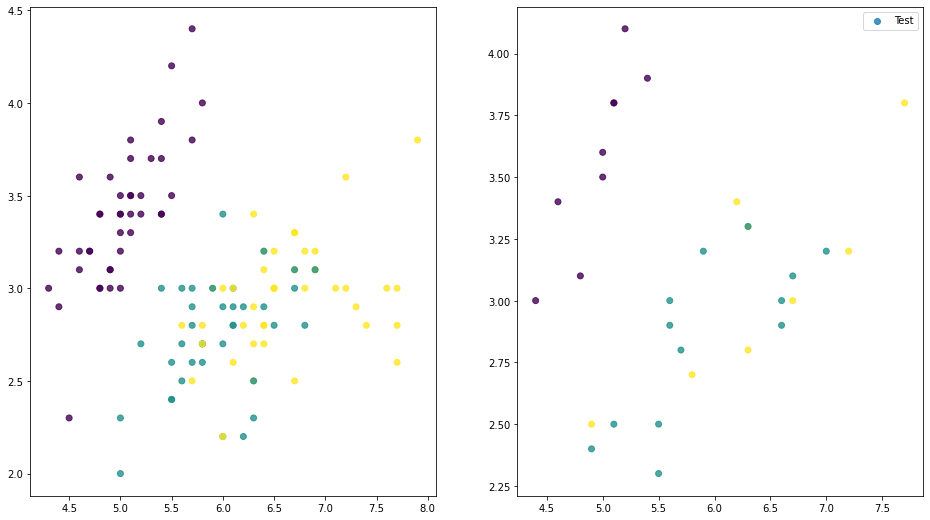

```python
plt.figure(figsize=(16, 9))

plt.subplot(121)
plt.scatter(X_train[:, 0], X_train[:, 1], c=y_train, alpha=.8, label='Train')

plt.subplot(122)
plt.scatter(X_test[:, 0], X_test[:, 1], c=y_test, alpha=.8, label='Test')

plt.legend()
```

```python
# C'est parti pour le machine Learning
model = KNeighborsClassifier()

model.fit(X_train, y_train)
print('Train score:', model.score(X_train, y_train))
print('Test score:', model.score(X_test, y_test))
```

```
Train score: 0.975
Test score: 0.9333333333333333
```

Not bad ! On a une plutot bonne précision, même sur le jeux de test !

Cependant, qu'est ce qui nous dit que l'on a pris un bon train set pas biaisé ? Pour pallier à cela, il y a ce que l'on appelle la **cross-validation** !

Le but est simple :

- on divise notre jeu de données en 5
- on va commencer pas train avec les 4 premieres partie et test sur la 5e
- puis on change un jeu de test et un jeu de train et ainsi de suite (5 fois du coup)
- Finalement on évalue les performances (des 5 modèles ici) et on fait la moyenne

Allez, testons cela !

```python
from sklearn.model_selection import cross_val_score
```

```python
# 5 jeux de données donc cv = 5
scores = cross_val_score(KNeighborsClassifier(), X_train, y_train, cv=5)
scores
```

```
array([1.   , 1.   , 1.   , 0.875, 1.   ])
```

```python
# On a donc obtenu 5 scores
scores.mean()
```

```
0.975
```

```python
# Testons pour combien de voisin c'est le mieux :
best_score = {
    'n_neighbors': 1,
    'score': 0.0
}

for i in range(1, 10):
    scores = cross_val_score(KNeighborsClassifier(i), X_train, y_train, cv=5).mean()
    if scores > best_score.get('score'):
        best_score.update({
            'n_neighbors': i,
            'score': scores
        })

best_score
```

```
{'n_neighbors': 6, 'score': 0.9833333333333332}
```

```python
# Tout ceci, c'est ce que fait cette fonction :
from sklearn.model_selection import validation_curve

model = KNeighborsClassifier()
n = np.arange(1, 20)

train_score, val_score = validation_curve(model, X_train, y_train, 'n_neighbors', n, cv=5)
```

```python
print(val_score.mean(axis=1))
val_score.shape
```

```
[0.96666667 0.95833333 0.96666667 0.96666667 0.975      0.98333333
 0.975      0.975      0.975      0.96666667 0.975      0.96666667
 0.975      0.95833333 0.95       0.95       0.95833333 0.95
 0.94166667]
```

```
(19, 5)
```

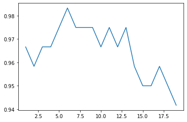

```python
# Evolution des score suivant le nombre de voisins
plt.plot(n, val_score.mean(axis=1))
```

Cependant... dans notre model il y a encore d'autre variables que l'on peut changer... Pour pouvoir TOUT tester d'un seul coup, il existe GridSearchCV !

```python
from sklearn.model_selection import GridSearchCV
```

```python
# On set les paramètres que l'on souhaite faire varier
param_grid = {
    'n_neighbors': np.arange(1, 10),
    'metric': ['euclidean', 'manhattan', 'minkowski']
}

# On set le model avec le model que l'on souhaite utiliser et les paramètres choisis
grid = GridSearchCV(KNeighborsClassifier(), param_grid=param_grid, cv=5)

# On entraine le modèle
grid.fit(X_train, y_train)
```

```
GridSearchCV(cv=5, estimator=KNeighborsClassifier(),
             param_grid={'metric': ['euclidean', 'manhattan', 'minkowski'],
                         'n_neighbors': array([1, 2, 3, 4, 5, 6, 7, 8, 9])})
```

```python
print('Best score :', grid.best_score_)
print('Best parameters :', grid.best_params_)
```

```
Best score : 0.9833333333333332
Best parameters : {'metric': 'euclidean', 'n_neighbors': 6}
```

```python
# On set notre model avec les meileurs paramètres trouvés
model = grid.best_estimator_
```

```python
# On test notre modèle
model.score(X_test, y_test)
```

```
0.9
```

Un dernier point utile est la confusion matrix, qui permet de facilement évaluer la qualité d'un modèle de classification en montrant les eurreurs de classement :

```python
from sklearn.metrics import confusion_matrix
```

```python
confusion_matrix(y_test, model.predict(X_test))
```

```
array([[ 9,  0,  0],
       [ 0, 12,  1],
       [ 0,  2,  6]], dtype=int64)
```

Maintenant, un point intéressant serait d'analyser si avec plus de données le modèle aurait de meilleurs performances. Pour étudier cela, on va regarder la Learning Curve:

```python
from sklearn.model_selection import learning_curve
```

```
[ 9 19 28 38 48 57 67 76 86 96]
```

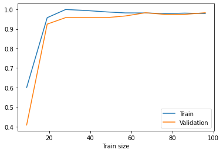

```python
# cv = cross validation
# Train size va tester ici avec
# 10% du lot (début linspace : .1)
# 20% du lot (début + fin/pas : .1 + 1/10 = .2)
# ...
# 100% du lot (fin linspace : 1.0)
N, train_score, val_score = learning_curve(model, X_train, y_train,
                                           train_sizes=np.linspace(.1, 1.0, 10), cv=5)

print(N)
plt.plot(N, train_score.mean(axis=1), label='Train')
plt.plot(N, val_score.mean(axis=1), label='Validation')
plt.xlabel('Train size')
plt.legend()
```

On voit là qu'à partir d'environ 70% du dataset, les performances n'évoluent plus beaucoup. Il serait donc inutile d'avoir beaucoup plus de données.

Back to top

## 3. Résumé

Après savoir ce que l'on cherche (regression, classification), on choisi un modèle qui correspond à notre problème, puis :

1. On commence par mélanger puis diviser notre dataset avec `train_test_split` :
   - Une partie d'entrainement (4/5 du dataset), elle même découpée en plusieurs sous ensemble (n) pour faire de la cross-validation. Parmis les n découpes, une servira à valider le modèle tandis que les autres serviront à l'entrainer. Le but étant ensuite de tester les n combinaisons possible de découpes, pour en faire la moyenne et avoir une vue assez générale de la qualité de ce dernier.
   - Une partie de test (1/5 du dataset en général) permettant de tester le model une fois choisi et entrainé.
2. On peut utiliser l'optimisateur `grid_search` pour trouver les meilleurs paramètres pour notre modèle (avec de la cross validation)
3. On utilise les courbes de validation et d'apprentissage pour valider la qualité du modèle, vérifier que l'on n'a pas sur-appris ou à l'inverse, pas assez (donc il faut plus de données).

Cependant, il est intéressant de noter que la cross validation est assez peu utilisée en Deep Learning. En effet, entrainer un modèle en DL peut prendre des heures. Entrainer 3, 4, 5 fois ou plus un modèle de DL signifie donc multiplier par autant ce nombre d'heures, c'est donc trop long !

D'autres techniques d'entrainement et dévaluation existent :

- K fold : très semblable à ce qui est présenté ci-dessus
- LeaveOneOut : autant de cross validation que de données (du coup oui c'est TRES long !)
- Shuffle Split : on mélange le jeux d'entrainement et on prend un jeu de validation random dedans. Puis on entraine notre modèle et on recommance. Il faudra donc précisé le nombre d'itération et la proportion du dataset de validation parmis l'ensemble.
- Stratified Fold : très utilisé, mix K-Fold et Shuffle Split. En gros on tri par classe et on prends proportionnellement n carte de chaque classe aléatoirement. Il faudra préciser le nombre d'itération
- Group KFold : Quand les données dépendent les unes des autres (par exemple on regarde les maladies, possiblement elles sont génétiques donc il y a un facteur d'influence). Ici on va trier les groupes et split tous les groupes en n découpe. Enfin pour chaque groupe on va regrouper les les jeux de données pour entrainer le modèle.

Back to top

## 4. Modèles de regression et erreurs

Il y a plusieurs technique pour calculer l'erreur et donc le cout d'un modèle. Les deux plus connus sont :

- MAE (Mean Absolute Error), qui consite à simplement prendre les distances entre les points et la courbe, puis de diviser le tout par le nombre de valeurs. Donc on fait la moyenne de toutes les erreurs (indépendamment de leur signe !).
- MSE (Mean Squared Error), c'est la même choses, mais toutes les erreurs sont mises au carré. Ainsi, le poid d'une erreur augmente exponentiellement avec sa distance à la courbe
- RMSE (Root Mean Squared Error), la valeur précédente, mais dont on fait la racine carrée

Quand utiliser la MAE ou la MSE (ou RMSE) ? C'est simple, si plus l'erreur augmente, plus elle est grave, il faut utiliser la MSE.

- Par exemple, en conduite autonome, on veut absolument limiter au maximum l'erreur tant une grande erreur décuple les impacts. Donc on utilise MSE.
- De l'autre coté, s'il peut y avoir des aberrations et qu'elles n'ont pas un impact critique, alors autant utiliser la MAE qui donnera de meilleurs performances au modèle.

D'ailleurs MAE peut aussi signifier Median Absolute Error, cette technique va accorder très peu d'importance aux grandes erreurs et plus aux petites. C'est notamment utile avec un capteur qui peut avoir quelques valeurs aberrantes mais dont on ne souhaite pas vraiment les considérer.

```python
from sklearn.metrics import *
```

```python
y = np.array([1, 2, 3, 4, 5, 15])
y_pred = np.array([0, 2, 3, 3, 4, 30])

print('MAE : ', mean_absolute_error(y, y_pred))
print('MSE : ', mean_squared_error(y, y_pred))
print('RMSE : ', np.sqrt(mean_squared_error(y, y_pred)))
print('Median AE : ', median_absolute_error(y, y_pred))
```

```
MAE :  3.0
MSE :  38.0
RMSE :  6.164414002968976
Median AE :  1.0
```

on voit bien ici que l'erreur moyenne est relativement bonne, mais que l'erreur quadratique est très forte.

Testons avec une valeur vraiment aberrante :

```python
y = np.array([1, 2, 3, 4, 5, 10])
y_pred = np.array([0, 2, 3, 3, 4, 10e6])

print('MAE : ', mean_absolute_error(y, y_pred))
print('MSE : ', mean_squared_error(y, y_pred))
print('RMSE : ', np.sqrt(mean_squared_error(y, y_pred)))
print('Median AE : ', median_absolute_error(y, y_pred))
```

```
MAE :  1666665.5
MSE :  16666633333350.5
RMSE :  4082478.8221557867
Median AE :  1.0
```

On voit bien ici qu'à cause d'une erreur vraiment aberrante, les erreurs s'affolent, surtout la MSE, alors que la Median ne la considère pas (ou très peu).

Au quotidien, si on ne sait pas vraiment quoi choisir, autant choisir tout en même temps. Prenant toutes ces métriques en même temps ! Prenons l'exemple du dataset du prix de l'immobilier de Boston. On va entrainer un modèle linéaire, puis analyser ses erreurs très rapidement :

```python
# Petit exemple :
from sklearn.datasets import load_boston
```

```python
boston = load_boston()
X = boston.data
y = boston.target
```

```python
# Oui on a dit qu'il ne fallait pas faire ça avant mais c'est juste pour le test :)
# Sinon, oui il faut split notre dataset et surtout ne pas l'evaluer avec ses datas
# d'entrainement
model = LinearRegression()
model.fit(X, y)
y_pred = model.predict(X)
```

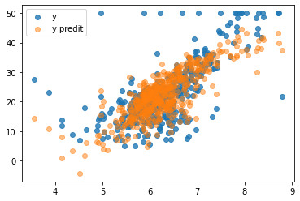

```python
plt.scatter(X[:, 5], y, alpha=.8, label='y')
plt.scatter(X[:, 5], y_pred, alpha=.5, label='y predit')
plt.legend()
```

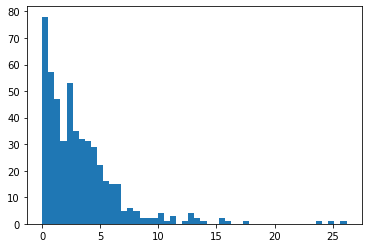

```python
# étudions la médiane, le quintile...

err_hist = np.abs(y - y_pred)
plt.hist(err_hist, bins=50)
plt.show()
```

On voit bien là que parmis toutes les predictions, presque 80 ont eu pas ou peu d'erreur (proche de 0), que globalement, les erreurs sont inférieurs à 10k dollars et qu'il y a quelques outliers (valeurs aberrantes) avec une erreur autour de 25k dollars.

Enfin, regardons un peu le coeficient de détermination. C'est ce que nous retourne la fonction score de Scikit :

```python
model.score(X, y)
```

```
0.7406426641094095
```

Plus c'est proche de 1, mieux c'est.

La fonction mathématique pour le calculer est très simple : $$ R2 = 1 - \frac{\Sigma(y_{vrai} - y_{pred})²}{\Sigma(y_{vrai} - \overline{y_{vrai}})²} $$ Avec :

- $\Sigma(y_{vrai} - y_{pred})²$ qui est l'erreur quadratique : évalue la PERFORMANCE
- $\Sigma(y_{vrai} - \overline{y_{vrai}})²$ qui est la variance ($\overline{y_{vrai}}$ c'est la moyenne des y) : évalue la VARIATION

Donc on étudie la performance du modèle par rapport au niveau de variation des données.

Quand les erreurs sont minimes comparé à la variance, la fraction tend vers 0 et donc R2 se rapproche de 1. Si les erreurs sont égales ou plus grandes que les variations, alors R2 tendra vers 0, voir sera même négatif !

Pour revenir à nos 74%, on peut donc dire que *le modèle décrit 74% des variations du prix de l'immobilier à Boston*.

On peut d'ailleurs utiliser cela pour les cross validations :

```python
cross_val_score(LinearRegression(), X, y, cv=5, scoring='neg_mean_absolute_error')
```

```
array([-2.62190565, -3.90725478, -4.386606  , -5.57073637, -4.76333993])
```

```python
# Si vous le souhaitez, voici toutes les metrics possibles :
import sklearn
sorted(sklearn.metrics.SCORERS.keys())
```

```
['accuracy',
 'adjusted_mutual_info_score',
 'adjusted_rand_score',
 'average_precision',
 'balanced_accuracy',
 'completeness_score',
 'explained_variance',
 'f1',
 'f1_macro',
 'f1_micro',
 'f1_samples',
 'f1_weighted',
 'fowlkes_mallows_score',
 'homogeneity_score',
 'jaccard',
 'jaccard_macro',
 'jaccard_micro',
 'jaccard_samples',
 'jaccard_weighted',
 'max_error',
 'mutual_info_score',
 'neg_brier_score',
 'neg_log_loss',
 'neg_mean_absolute_error',
 'neg_mean_gamma_deviance',
 'neg_mean_poisson_deviance',
 'neg_mean_squared_error',
 'neg_mean_squared_log_error',
 'neg_median_absolute_error',
 'neg_root_mean_squared_error',
 'normalized_mutual_info_score',
 'precision',
 'precision_macro',
 'precision_micro',
 'precision_samples',
 'precision_weighted',
 'r2',
 'recall',
 'recall_macro',
 'recall_micro',
 'recall_samples',
 'recall_weighted',
 'roc_auc',
 'roc_auc_ovo',
 'roc_auc_ovo_weighted',
 'roc_auc_ovr',
 'roc_auc_ovr_weighted',
 'v_measure_score']
```

Back to top

## 5. Pre-processing

Le model apprend des données qui lui sont données. Il est donc très important de lui donner de bonnes données. On va avoir plusieurs étapes :

- L'encodage : passage de data qualitatives (textes, labels...) à des datas numériques
- La normalisation : mise sous une même échelle des datas quantitatives pour grandement faciliter l'apprentissage de la machine
- L'imputation : remplacement des données manquantes par certaines datas statistiques
- La selection de variable : test statistiques (comme le khi²) pour trouver les variables les plus utiles (et ne garder qu'elles)
- L'extraction de caractéristiques : extraire des données cachées dans un dataset (IMC => poids et taille)

Pour tout ceci, SKLearn a de nombreux modules comme `preprocessing` pour l'encodage et la normalisation, `impute` pour l'imputation, `feature_selection` et `feature_extraction` pour les deux dernières étapes.

Pour le moment, restons sur le pre-processing, et surtout les transformers (les fonctions avec des majuscules). Les transformer permettent de transformer de manière cohérente des données d'un modèle. Associé à l'estimateur, on obtient une pipeline (une chaine de transformation) :

X_test ---> TRANSFORMER ===> ESTIMATEUR ---> y_pred

### 5.1. Encodage

Commençons par transformer les labels en valeurs numériques. Dans SK, il existe 5 fonctions d'encodage dans le module `preprocessing`:

- `LabelBinarizer`
- `LabelEncoder`
- `MultiLabelBinarizer`
- `OneHotEncoder`
- `OrdinalEncoder`

Il y a deux type d'encodage :

- Ordinal : associer une classe une valeur numérique (ex : voiture = 1, avion = 2...)

```python
import sklearn.preprocessing
```

```python
# On créé nos datas
y = np.array(['Tortue', 'Baleine', 'Chat', 'Loup', 'Aigle', 'Tortue', 'Loup', 'Tortue'])

# On prend un encoder
encoder = sklearn.preprocessing.LabelEncoder()
# On le fait travailler
encoder.fit(y)

# Voyons le résultat
encoder.classes_
```

```
array(['Aigle', 'Baleine', 'Chat', 'Loup', 'Tortue'], dtype='<U7')
```

```python
# On test :
encoder.transform(y)
```

```
array([4, 1, 2, 3, 0, 4, 3, 4], dtype=int64)
```

```python
# Pour aller plus vite on peut directement faire cela :
y = np.array(['Tortue', 'Baleine', 'Chat', 'Loup', 'Aigle', 'Tortue', 'Loup', 'Tortue'])

encoder = sklearn.preprocessing.LabelEncoder()
encoder.fit_transform(y)
```

```
array([4, 1, 2, 3, 0, 4, 3, 4], dtype=int64)
```

```python
# En sens inverse, on peut inverser l'opération pour retrouver les données :
encoder.inverse_transform(np.array([1,1,3,2,4,0]))
```

```
array(['Baleine', 'Baleine', 'Loup', 'Chat', 'Tortue', 'Aigle'],
      dtype='<U7')
```

```python
# Cependant, tout ceci ne fonctionne pas si on a un tableau à deux dimensions.
# On devra donc utiliser OrdinalEncoder

y = np.array([
    ['Tortue', 'Eau'],
    ['Baleine', 'Eau'],
    ['Loup', 'Terre'],
    ['Aigle', 'Air'],
    ['Tortue', 'Eau'],
    ['Aigle', 'Air'],
    ['Baleine', 'Eau'],
    ['Loup', 'Terre'],
    ['Tortue', 'Eau']
])


encoder = sklearn.preprocessing.OrdinalEncoder()
encoder.fit_transform(y)
```

```
array([[3., 1.],
       [1., 1.],
       [2., 2.],
       [0., 0.],
       [3., 1.],
       [0., 0.],
       [1., 1.],
       [2., 2.],
       [3., 1.]])
```

Cependant ici, on a créé un ordre, les tortues sont supérieures aux loups. Bien que parfait pour les arbres de décisions (qui ne s'intèresse pas à l'ordre des valeurs), cet ordre influe sur certains modèles de ML. Il existe un autre encodage :

- le One Hot : il créé une matrice et associe à chaque valeurs un 1 ou un 0 dans la colonne le correspondant:

```python
y = np.array(['Tortue', 'Baleine', 'Loup', 'Aigle', 'Tortue', 'Loup', 'Tortue'])

# On peut aussi utiliser MultiLabelBinarizer ou encore OneHotEncoder
encoder = sklearn.preprocessing.LabelBinarizer()
encoder.fit_transform(y)
```

```
array([[0, 0, 0, 1],
       [0, 1, 0, 0],
       [0, 0, 1, 0],
       [1, 0, 0, 0],
       [0, 0, 0, 1],
       [0, 0, 1, 0],
       [0, 0, 0, 1]])
```

```python
y = np.array([
    ['Tortue', 'Eau'],
    ['Baleine', 'Eau'],
    ['Loup', 'Terre'],
    ['Aigle', 'Air'],
    ['Tortue', 'Eau'],
    ['Aigle', 'Air'],
    ['Baleine', 'Eau'],
    ['Loup', 'Terre'],
    ['Tortue', 'Eau']
])

encoder = sklearn.preprocessing.MultiLabelBinarizer()
encoder.fit_transform(y)
```

```
array([[0, 0, 0, 1, 0, 0, 1],
       [0, 0, 1, 1, 0, 0, 0],
       [0, 0, 0, 0, 1, 1, 0],
       [1, 1, 0, 0, 0, 0, 0],
       [0, 0, 0, 1, 0, 0, 1],
       [1, 1, 0, 0, 0, 0, 0],
       [0, 0, 1, 1, 0, 0, 0],
       [0, 0, 0, 0, 1, 1, 0],
       [0, 0, 0, 1, 0, 0, 1]])
```

On a ici une matrice creuse (beaucoup de 0) donc prenant en fait très peu de place quand on la stock en CSR : Compressed Sparse Row. Par exemple :

```
| 0 0 0 a 0 0 |
| 0 0 0 0 0 0 |
| 0 0 0 0 e 0 |
| 0 0 0 0 0 0 |
| 0 c 0 0 0 0 |
```

Ici, on peut simplement stocker :

[output not shown]

On peut donc choisir de compresser ou non le résultat avec `sparse_output` :

```python
y = np.array([
    ['Tortue', 'Eau'],
    ['Baleine', 'Eau'],
    ['Loup', 'Terre'],
    ['Aigle', 'Air'],
    ['Tortue', 'Eau'],
    ['Aigle', 'Air'],
    ['Baleine', 'Eau'],
    ['Loup', 'Terre'],
    ['Tortue', 'Eau']
])

encoder = sklearn.preprocessing.MultiLabelBinarizer(sparse_output=True)
encoder.fit_transform(y)
```

```
<9x7 sparse matrix of type '<class 'numpy.int32'>'
	with 18 stored elements in Compressed Sparse Row format>
```

Cependant, attention, SK gère mal l'apparition de nouveaux élément (par exemple si là on ajoute un chien). Il peut donc être parfois intéressant de refaire sa propre fonction pour gérer cela.

### 5.2. Normalisation

On va voir les 3 principales fonctions :

- MinMaxScaler
- RobustScaler
- StandardScaler

```python
X = np.array([[34], [44], [120]])

scaler = sklearn.preprocessing.MinMaxScaler()
scaler.fit_transform(X)
```

```
array([[0.        ],
       [0.11627907],
       [1.        ]])
```

```python
# On réapplique la même transformation sur de nouvelles datas.
scaler.transform(np.array([[12], [185]]))
```

```
array([[-0.25581395],
       [ 1.75581395]])
```

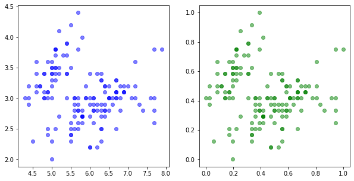

```python
# Testons avec nos Iris
iris = load_iris()
X = iris.data

X_min_max = sklearn.preprocessing.MinMaxScaler().fit_transform(X)

plt.figure(figsize=(10,5))

plt.subplot(121)
plt.scatter(X[:, 0], X[:, 1], alpha=.5, c='b')

plt.subplot(122)
plt.scatter(X_min_max[:, 0], X_min_max[:, 1], alpha=.5, c='g')
plt.show()
```

On voit bien ici que les échelles ne sont pas les mêmes, mais les proportions sont gardées. C'est tout ce qui compte pour la machine.

Une autre technique est la **standardisation**. Très utilisée, elle consiste à chercher à avoir une moyenne à 0 et un écart-type à 1:

```python
X = np.array([[34], [44], [120]])

scaler = sklearn.preprocessing.StandardScaler()
X_stand = scaler.fit_transform(X)

print('Moyenne :', X_stand.mean())
print('Écart type :', X_stand.std())
X_stand
```

```
Moyenne : 0.0
Écart type : 0.9999999999999998
```

```
array([[-0.83330319],
       [-0.57289595],
       [ 1.40619914]])
```

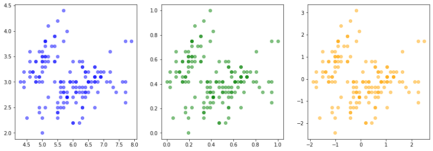

```python
# Testons avec nos Iris
iris = load_iris()
X = iris.data

X_min_max = sklearn.preprocessing.MinMaxScaler().fit_transform(X)
X_std_scl = sklearn.preprocessing.StandardScaler().fit_transform(X)

plt.figure(figsize=(15,5))

plt.subplot(131)
plt.scatter(X[:, 0], X[:, 1], alpha=.5, c='b')

plt.subplot(132)
plt.scatter(X_min_max[:, 0], X_min_max[:, 1], alpha=.5, c='g')

plt.subplot(133)
plt.scatter(X_std_scl[:, 0], X_std_scl[:, 1], alpha=.5, c='orange')
plt.show()
```

Tout ceci est très puissant, cependant, si jamais il y a des valeurs aberrantes, ces techniques sont très sensibles !

Dans ce cas il faudra faire appel au RobustScaler. On ne soustrait pas chaque data à sa moyenne mais à se médiane, puis on ne divise pas par l'écart type mais par l'interquartile (écart entre 25% et 75% des datas).

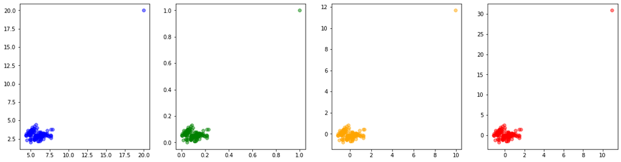

```python
# Testons avec nos Iris
iris = load_iris()
X = np.concatenate((iris.data, np.array([[20.0, 20.0, 20.0, 100.0]])), axis=0)

X_min_max = sklearn.preprocessing.MinMaxScaler().fit_transform(X)
X_std_scl = sklearn.preprocessing.StandardScaler().fit_transform(X)
X_rob_scl = sklearn.preprocessing.RobustScaler().fit_transform(X)

plt.figure(figsize=(20,5))

plt.subplot(141)
plt.scatter(X[:, 0], X[:, 1], alpha=.5, c='b')

plt.subplot(142)
plt.scatter(X_min_max[:, 0], X_min_max[:, 1], alpha=.5, c='g')

plt.subplot(143)
plt.scatter(X_std_scl[:, 0], X_std_scl[:, 1], alpha=.5, c='orange')

plt.subplot(144)
plt.scatter(X_rob_scl[:, 0], X_rob_scl[:, 1], alpha=.5, c='r')
plt.show()
```

### 5.3. Feature engineering

Consiste à créer de nouvelles variables à partir d'une première :

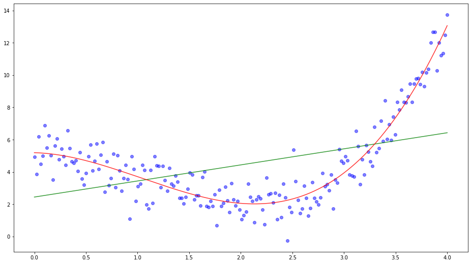

```python
n = 200
X = np.linspace(0, 4, n).reshape((n, 1))
y = X**2 + 5*np.cos(X) + np.random.randn(n, 1)

plt.figure(figsize=(16, 9))
plt.scatter(X, y, alpha=.5, c='b')

# Modèle linéaire ne fit pas vraiment
model = LinearRegression().fit(X, y)
y_pred = model.predict(X)
plt.plot(X, y_pred, alpha=.8, c='g')

# On créé un model polynomial de degré 3 à partir du lineaire
x_polynomial = sklearn.preprocessing.PolynomialFeatures(3).fit_transform(X)

model = LinearRegression().fit(x_polynomial, y)
y_pred = model.predict(x_polynomial)
plt.plot(X, y_pred, alpha=.8, c='r')
```

Parlons finalement des Binarizer qui permettent de créer des catégories, imaginons pour des ages :

```python
X = np.linspace(0, 80, 10).reshape((10, 1))

# Binarizer
threshold = X.max()/2
X_bin = sklearn.preprocessing.Binarizer(threshold=threshold).fit_transform(X)
np.concatenate((X, X_bin), axis=1)
```

```
array([[ 0.        ,  0.        ],
       [ 8.88888889,  0.        ],
       [17.77777778,  0.        ],
       [26.66666667,  0.        ],
       [35.55555556,  0.        ],
       [44.44444444,  1.        ],
       [53.33333333,  1.        ],
       [62.22222222,  1.        ],
       [71.11111111,  1.        ],
       [80.        ,  1.        ]])
```

```python
# KBinsDiscretizer
bins = int(X.max()//20)
x_disc = sklearn.preprocessing.KBinsDiscretizer(n_bins=bins).fit_transform(X).toarray()
np.concatenate((X, x_disc), axis=1)
```

```
array([[ 0.        ,  1.        ,  0.        ,  0.        ,  0.        ],
       [ 8.88888889,  1.        ,  0.        ,  0.        ,  0.        ],
       [17.77777778,  1.        ,  0.        ,  0.        ,  0.        ],
       [26.66666667,  0.        ,  1.        ,  0.        ,  0.        ],
       [35.55555556,  0.        ,  1.        ,  0.        ,  0.        ],
       [44.44444444,  0.        ,  0.        ,  1.        ,  0.        ],
       [53.33333333,  0.        ,  0.        ,  1.        ,  0.        ],
       [62.22222222,  0.        ,  0.        ,  0.        ,  1.        ],
       [71.11111111,  0.        ,  0.        ,  0.        ,  1.        ],
       [80.        ,  0.        ,  0.        ,  0.        ,  1.        ]])
```

### 5.4. Nettoyage des données

Dans SciKit, il existe les `imputer`, qui permettent de nettoyer les données. Il en existe plusieurs, on va dabors se concentrer sur le plus simple : `SimpleImputer`

```python
from sklearn.impute import SimpleImputer
```

```python
# Créons un dataset avec une data mauvaise (via np.nan)
X = np.array([
    [46, 2],
    [4, 25],
    [2, 83],
    [np.nan, 0]
])
```

```python
# On va la remplacer :
imputer = SimpleImputer(
    missing_values=np.nan,  # On indique ce que l'on cherche
    strategy='mean',  # On indique comment / par quoi on le remplace : moyenne, median, plus fréquent, constante
)
imputer.fit_transform(X)
```

```
array([[46.        ,  2.        ],
       [ 4.        , 25.        ],
       [ 2.        , 83.        ],
       [17.33333333,  0.        ]])
```

```python
# Ajoutons une ligne de np.nan
X = np.concatenate((X, [[np.nan, np.nan]]), axis=0)

# On retransforme :
imputer.transform(X)
```

```
array([[46.        ,  2.        ],
       [ 4.        , 25.        ],
       [ 2.        , 83.        ],
       [17.33333333,  0.        ],
       [17.33333333, 27.5       ]])
```

Voyons maintenant un second Imputer, très intéressant et simple : le `KNNImputer` (K Nearest Neighbours Imputer).

Il va chercher les plus proches voisins et remplacer les valeurs manquantes par des valeurs proches de celle des voisins. Par exemple :

```python
from sklearn.impute import KNNImputer
```

```python
X = np.array([
    [1, 1],
    [2, np.nan],
    [3, 9],
    [4, 16],
    [5, 25],
    [6, 36],
    [7, 49],
    [8, 64],
    [9, 81],
    [10, 100],
])
KNNImputer(n_neighbors=2).fit_transform(X)
```

```
array([[  1.,   1.],
       [  2.,   5.],
       [  3.,   9.],
       [  4.,  16.],
       [  5.,  25.],
       [  6.,  36.],
       [  7.,  49.],
       [  8.,  64.],
       [  9.,  81.],
       [ 10., 100.]])
```

Donc ici, on voit que pour la valeur $x_1$, on a eu la valeur 5 ( moyenne des voisins, ici 2 : $ \frac{X_{1+1}-X_{1-1}}{2}+X_{1-1} = \frac{9-1}{2}+1 = 4 + 1 = 5 $ ). Si on avait pris la moyenne ou la médiane on aurait :

```python
liste_carres = np.arange(1, 10)**2
print('Moyenne :', liste_carres.mean())
print('Médiane :', liste_carres[len(liste_carres)//2])
```

```
Moyenne : 31.666666666666668
Médiane : 25
```

Ce qui n'a donc pas l'air de correspondre à la tendance.

Enfin, un dernier plutôt sympa : `MissingIndicator`. Il est très simple, il indique les endroits où il nous manque des datas :

```python
from sklearn.impute import MissingIndicator
```

```python
X = np.array([
    [46, 2],
    [4, 25],
    [2, 83],
    [np.nan, 0],
    [np.nan, np.nan]
])

MissingIndicator().fit_transform(X)
```

```
array([[False, False],
       [False, False],
       [False, False],
       [ True, False],
       [ True,  True]])
```

Alors quelle serait l'utilité ? Imaginons que l'on prenne les passagers du Titanic, possiblement que les passagers qui n'ont pas payé de fare, sont en fait des membres d'équipage. Ce qui serait donc normal et on chercherait donc à les traiter différemment.

Ici on devrait séparer les deux groupes pour faire des traitements différent. Comme nous le verons plus tard, il y a la pipeline `MakeUnion` qui nous permettra cela : on traitera en parallèle les deux tableaux Passager et Equipage, puis nous les rassembleront pour le modèle.

```python
from sklearn.pipeline import make_union
pipeline = make_union(SimpleImputer(strategy='constant', fill_value=-99),
                     MissingIndicator())
pipeline.fit_transform(X)
```

```
array([[ 46.,   2.,   0.,   0.],
       [  4.,  25.,   0.,   0.],
       [  2.,  83.,   0.,   0.],
       [-99.,   0.,   1.,   0.],
       [-99., -99.,   1.,   1.]])
```

Bref, finalement pourquoi utiliser ces fonctions d'Imputation plutot que ce que l'on peut faire avec Pandas ? Parce que l'on peut utiliser les pipelines et en plus, KNNImputer est très puissant pour faire un remplacement que pandas ne sait pas faire.

Back to top

## 6. Pipeline

Il est temps de coupler le transformer et l'estimateur grâce à la Pipeline !

```python
# Si on reprends tout pour le moment, on a :
X = iris.data
y = iris.target

# Split dataset : Entrainement et Test
X_train, X_test, y_train, y_test = sklearn.model_selection.train_test_split(X, y, test_size=.2)

# Transformer
scaler = sklearn.preprocessing.StandardScaler()
X_train_transformed = scaler.fit_transform(X_train)

# Estimateur
model = sklearn.linear_model.SGDClassifier(random_state=0)
model.fit(X_train_transformed, y_train)

# Test
X_test_transformed = scaler.transform(X_test)
y_pred = model.predict(X_test_transformed)

print('Score :', model.score(X_test_transformed, y_pred))
y_pred
```

```
Score : 1.0
```

```
array([2, 0, 2, 1, 1, 0, 1, 0, 2, 0, 1, 0, 0, 1, 1, 0, 0, 1, 1, 2, 2, 0,
       2, 1, 2, 2, 0, 1, 0, 2])
```

Tout ceci c'est bien mais c'est long. C'est là qu'intervient la Pipeline pour faire un *estimateur composite* en regroupant toutes ces étapes. L'estimateur a donc aussi un fit, predict et d'une méthode score :

```python
from sklearn.pipeline import make_pipeline
```

```python
# On créé la pipeline
model = make_pipeline(sklearn.preprocessing.StandardScaler(),
                      sklearn.linear_model.SGDClassifier())

# On train
model.fit(X_train, y_train)

# On prédit
y_pred = model.predict(X_test)

# On affiche
print('Score :', model.score(X_test, y_pred))
y_pred
```

```
Score : 1.0
```

```
array([2, 0, 2, 1, 1, 0, 1, 0, 2, 0, 1, 0, 0, 1, 1, 0, 0, 1, 1, 2, 2, 0,
       2, 1, 2, 2, 0, 1, 0, 2])
```

On obtient exactement le même résultat. C'est donc la même chose mais en plus :

- lisible et simple à utiliser
- sécurise les données (et notamment leur transformation)
- permet de faire des cross validations sur toute la chaine de transformation :

```python
# On créé la pipeline
model = make_pipeline(sklearn.preprocessing.PolynomialFeatures(),
                      sklearn.preprocessing.StandardScaler(),
                      sklearn.linear_model.SGDClassifier(random_state=0))
params = {
    'polynomialfeatures__degree': [2, 3, 4],
    'sgdclassifier__penalty': ['l1', 'l2']
}

grid = sklearn.model_selection.GridSearchCV(model, param_grid=params, cv=5)

# On train
grid.fit(X_train, y_train)

# On affiche
print('Score :', grid.score(X_test, y_pred))
print('Best param :', grid.best_params_)
```

```
Score : 1.0
Best param : {'polynomialfeatures__degree': 3, 'sgdclassifier__penalty': 'l1'}
```

```python
# On prédit
grid.predict(X_test)
```

```
array([2, 0, 2, 1, 1, 0, 1, 0, 2, 0, 1, 0, 0, 1, 1, 0, 0, 1, 1, 2, 2, 0,
       2, 1, 2, 2, 0, 1, 0, 2])
```

Continuons sur les pipelines en voyant des concepts plus avancés avec :

- `make_column_transformer`
- `make_column_selector`
- `make_union`

Ces fonctions seront notamment utiles lorsque l'on doit transformer un gros dataset avec des colonnes avec des transformations variées à apporter. Testons avec le dataset du Titanic :

```python
import seaborn as sns
from sklearn.compose import make_column_transformer
```

```python
titanic = sns.load_dataset('titanic')

# Analysons les chances de survit, donc c'est notre sortie :
y = titanic.survived
# Et le reste est l'entrée :
X = titanic.drop('survived', axis=1)

titanic.head()
```

|  | survived | pclass | sex | age | sibsp | parch | fare | embarked | class | who | adult_male | deck | embark_town | alive | alone |
| --- | --- | --- | --- | --- | --- | --- | --- | --- | --- | --- | --- | --- | --- | --- | --- |
| 0 | 0 | 3 | male | 22.0 | 1 | 0 | 7.2500 | S | Third | man | True | NaN | Southampton | no | False |
| 1 | 1 | 1 | female | 38.0 | 1 | 0 | 71.2833 | C | First | woman | False | C | Cherbourg | yes | False |
| 2 | 1 | 3 | female | 26.0 | 0 | 0 | 7.9250 | S | Third | woman | False | NaN | Southampton | yes | True |
| 3 | 1 | 1 | female | 35.0 | 1 | 0 | 53.1000 | S | First | woman | False | C | Southampton | yes | False |
| 4 | 0 | 3 | male | 35.0 | 0 | 0 | 8.0500 | S | Third | man | True | NaN | Southampton | no | True |

Ici, on voit bien que l'on a des colonnes aux formats variés. On va donc utiliser `make_column_transformer`, afin de n'appliquer une fonction de transformation que sur certaines colonnes :

```python
# Transformons seulement les colonnes age et fare avec StandardScaler :
transformer = make_column_transformer((sklearn.preprocessing.StandardScaler(),
                                       ['age', 'fare']))
transformer.fit_transform(X)
```

```
array([[-0.53037664, -0.50244517],
       [ 0.57183099,  0.78684529],
       [-0.25482473, -0.48885426],
       ...,
       [        nan, -0.17626324],
       [-0.25482473, -0.04438104],
       [ 0.15850313, -0.49237783]])
```

On voit donc bien que seulement de colonnes (age et fare) ont été transformé.

Avant de continuer, faisons deux listes de colonnes, l'une contenant du numérique, l'autre contenant des strings, puis refaisons de manière plus global notre column transformer. Pour ce faire, nous devrons créer des pipelines.

```python
# On sépare les noms de colonnes selon leurs types :
num_features = ['pclass', 'age', 'fare']  # Numerics
cat_features = ['sex', 'deck', 'alone']   # Categories
```

```python
# On créé nos pipelines :
num_pipeline = make_pipeline(SimpleImputer(),  # Pour gérer les valeurs manquantes
                             sklearn.preprocessing.StandardScaler())
cat_pipeline = make_pipeline(SimpleImputer(strategy='most_frequent'),
                             sklearn.preprocessing.OneHotEncoder())
```

```python
pre_process = make_column_transformer((num_pipeline, num_features),  # Num pipeline sur num features
                                      (cat_pipeline, cat_features))  # Cat pipeline sur cat features
```

```python
model = make_pipeline(pre_process, sklearn.linear_model.SGDClassifier())
model.fit(X, y)
```

```
Pipeline(steps=[('columntransformer',
                 ColumnTransformer(transformers=[('pipeline-1',
                                                  Pipeline(steps=[('simpleimputer',
                                                                   SimpleImputer()),
                                                                  ('standardscaler',
                                                                   StandardScaler())]),
                                                  ['pclass', 'age', 'fare']),
                                                 ('pipeline-2',
                                                  Pipeline(steps=[('simpleimputer',
                                                                   SimpleImputer(strategy='most_frequent')),
                                                                  ('onehotencoder',
                                                                   OneHotEncoder())]),
                                                  ['sex', 'deck', 'alone'])])),
                ('sgdclassifier', SGDClassifier())])
```

Et si jamais on a des dizaines, ou même, des centaines de features ? On écrit tout à la mano ? C'est mega long non ?

Et bien, jeune padawan... pas du tout. Scikit a rajouté (depuis la v0.22) le `column_selector` justement dans ce but : indiquer le type des colonnes à modifier, ou même, les colonnes respectant un pattern précis !

Testons ça :

```python
from sklearn.compose import make_column_selector
```

```python
# On load le dataset
titanic = sns.load_dataset('titanic')

# On sépare les features des sorties
y = titanic.survived
X = titanic.drop('survived', axis=1)

# On créé les selector
num_features = make_column_selector(dtype_include=np.number)
cat_features = make_column_selector(dtype_exclude=np.number)

# On créé nos pipelines :
num_pipeline = make_pipeline(SimpleImputer(),  # Pour gérer les valeurs manquantes
                             sklearn.preprocessing.StandardScaler())
cat_pipeline = make_pipeline(SimpleImputer(strategy='most_frequent'),
                             sklearn.preprocessing.OneHotEncoder())

# On créé notre transformer
pre_process = make_column_transformer((num_pipeline, num_features),  # Num pipeline sur num features
                                      (cat_pipeline, cat_features))  # Cat pipeline sur cat features

# On créé la pipeline
model = make_pipeline(pre_process, sklearn.linear_model.SGDClassifier())
# Et on entraine le modèle
model.fit(X, y)
```

```
Pipeline(steps=[('columntransformer',
                 ColumnTransformer(transformers=[('pipeline-1',
                                                  Pipeline(steps=[('simpleimputer',
                                                                   SimpleImputer()),
                                                                  ('standardscaler',
                                                                   StandardScaler())]),
                                                  <sklearn.compose._column_transformer.make_column_selector object at 0x00000209EC8CB880>),
                                                 ('pipeline-2',
                                                  Pipeline(steps=[('simpleimputer',
                                                                   SimpleImputer(strategy='most_frequent')),
                                                                  ('onehotencoder',
                                                                   OneHotEncoder())]),
                                                  <sklearn.compose._column_transformer.make_column_selector object at 0x00000209EB7865E0>)])),
                ('sgdclassifier', SGDClassifier())])
```

Enfin, voyons des pipelines parallèles (et non pas en série).

```python
from sklearn.pipeline import make_union
```

```python
# On load le dataset
titanic = sns.load_dataset('titanic')

titanic = titanic.dropna(axis=0)

# On sépare les features des sorties
y = titanic.survived
X = titanic.drop('survived', axis=1)
```

```python
# On va standardizer et discretiser les colonnes age et fare, en parallèle
pipeline = make_union(sklearn.preprocessing.StandardScaler(), sklearn.preprocessing.Binarizer())

# On fit
transform = pipeline.fit_transform(X[['age', 'fare']])

print(transform.shape)
print('On a : \n| age_scale | fare_scale | age_binarize | fare_binarize |')
transform[:10, :]
```

```
(182, 4)
On a :
| age_scale | fare_scale | age_binarize | fare_binarize |
```

```
array([[ 0.15208196, -0.10011013,  1.        ,  1.        ],
       [-0.03987502, -0.33848477,  1.        ,  1.        ],
       [ 1.17585249, -0.35470782,  1.        ,  1.        ],
       [-2.02343043, -0.81567192,  1.        ,  1.        ],
       [ 1.43179512, -0.68654298,  1.        ,  1.        ],
       [-0.10386068, -0.8641772 ,  1.        ,  1.        ],
       [-0.48777463, -0.56921262,  1.        ,  1.        ],
       [-1.06364555,  2.41320703,  1.        ,  1.        ],
       [ 0.8559242 , -0.0287169 ,  1.        ,  1.        ],
       [ 1.87969473, -0.22208257,  1.        ,  1.        ]])
```

Testons les Imputer que nous avions vu précédemment au chapitre 5. :

```python
titanic = sns.load_dataset('titanic')

y = titanic.survived
X = titanic[['pclass', 'age']]

X_train, X_test, y_train, y_test = train_test_split(X, y, test_size=.2)
```

```python
model = make_pipeline(KNNImputer(), sklearn.linear_model.SGDClassifier())
```

```python
params = {
    'knnimputer__n_neighbors': list(np.arange(1, 5))
}

grid = GridSearchCV(model, param_grid=params, cv=5)
```

```python
grid.fit(X_train, y_train)
```

```
GridSearchCV(cv=5,
             estimator=Pipeline(steps=[('knnimputer', KNNImputer()),
                                       ('sgdclassifier', SGDClassifier())]),
             param_grid={'knnimputer__n_neighbors': [1, 2, 3, 4]})
```

```python
grid.best_params_
```

```
{'knnimputer__n_neighbors': 2}
```

Back to top

## 7. Transformer - Feature selection

Dans le module `feature_selection`, on va retrouver plusieurs selecteurs, permettant de selectionner des colonnes selon l'intêrét qu'elle porte. On a plusieurs types de fonctions :

- Les selecteurs selon la variance de la variable
- Les selecteurs basés sur des tests statistiques (ex : chi² (Classification), percentile, Anova, Pearson (Corrélation)...)
- Les selecteurs basés estimateur de coef

Commencons par le premier : VarianceThreshold. Ce dernier étudie la variance de tout le dataset et supprime les features qui ont une variance trop faible. En effet, à quoi sert une variable qui ne varie pas ou peu ? A rien, voir c'est dangereux car cela peut dégrader le modèle.

```python
from sklearn.feature_selection import VarianceThreshold
```

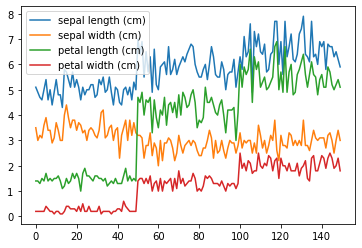

```python
iris = load_iris()
X = iris.data
y = iris.target

plt.plot(X)
plt.legend(iris.feature_names)
```

Ici on voit clairement que la sepal varie peu et surtout la largeur sepal.

Calculons les variances :

```python
pd.DataFrame({
    'Features': iris.feature_names,
    'Variance': X.var(axis=0)})
```

|  | Features | Variance |
| --- | --- | --- |
| 0 | sepal length (cm) | 0.681122 |
| 1 | sepal width (cm) | 0.188713 |
| 2 | petal length (cm) | 3.095503 |
| 3 | petal width (cm) | 0.577133 |

```python
selector = VarianceThreshold(threshold=.2)
selector.fit_transform(X)[:10, :]
```

```
array([[5.1, 1.4, 0.2],
       [4.9, 1.4, 0.2],
       [4.7, 1.3, 0.2],
       [4.6, 1.5, 0.2],
       [5. , 1.4, 0.2],
       [5.4, 1.7, 0.4],
       [4.6, 1.4, 0.3],
       [5. , 1.5, 0.2],
       [4.4, 1.4, 0.2],
       [4.9, 1.5, 0.1]])
```

On voit bien qu'une colonne a été supprimée, on peut savoir laquelle avec `get_support()` :

```python
print('Ont été selectionnés :', ', '.join(np.array(iris.feature_names)[selector.get_support()]), '.\n')

pd.DataFrame({
    'Features': iris.feature_names,
    'Variance': X.var(axis=0),
    'Selected': selector.get_support()
})
```

```
Ont été selectionnés : sepal length (cm), petal length (cm), petal width (cm) .
```

|  | Features | Variance | Selected |
| --- | --- | --- | --- |
| 0 | sepal length (cm) | 0.681122 | True |
| 1 | sepal width (cm) | 0.188713 | False |
| 2 | petal length (cm) | 3.095503 | True |
| 3 | petal width (cm) | 0.577133 | True |

Passons aux tests basés sur les dépendances et notamment KBest. C'est très simple, on va appliquer un test statistique (testons avec Chi2), puis on va prendre les K meilleures colonnes :

```python
from sklearn.feature_selection import SelectKBest, chi2
```

```python
# Exemple de Chi2
chi2(X, y)  # Score élevé = grosse dépendance
```

```
(array([ 10.81782088,   3.7107283 , 116.31261309,  67.0483602 ]),
 array([4.47651499e-03, 1.56395980e-01, 5.53397228e-26, 2.75824965e-15]))
```

```python
# Utilisons Chi2 et récupérons une seule feature :
selector = SelectKBest(chi2, k=1)

print(selector.fit_transform(X, y)[:10])
print('\nOnt été selectionnés :', ', '.join(np.array(iris.feature_names)[selector.get_support()]))
```

```
[[1.4]
 [1.4]
 [1.3]
 [1.5]
 [1.4]
 [1.7]
 [1.4]
 [1.5]
 [1.4]
 [1.5]]

Ont été selectionnés : petal length (cm)
```

Enfin, regardons le selecteur selon le modèle. On va préentrainer le modèle puis étudier le résultat pour déterminer si une feature était utile ou non.

Le fonctionnement est simple. Quand on entraine le modèle, ce dernier va chercher des coeficients à accorder à chaque feature, permettant de réduire au maximum la fonction cout et donc de prédire au mieux le modèle. Et bien ce sont ces coefs que nous regarderons. S'ils sont proche de 0, c'est qu'ils sont inutiles ($0 * n = 0$ donc pas d'impact).

Cependant ATTENTION, il faut donc forcément utiliser un modèle calculant des coefficient (donc pas KNN par exemple) !

```python
from sklearn.feature_selection import SelectFromModel
```

```python
# Cherchons les features supérieurs à la moyenne
selector = SelectFromModel(sklearn.linear_model.SGDClassifier(random_state=0),
                          threshold='mean')

selector.fit_transform(X, y)

print('Ont été selectionnés :', ', '.join(np.array(iris.feature_names)[selector.get_support()]))

# regardons rapidement les coefs :
selector.estimator_.coef_
```

```
Ont été selectionnés : petal length (cm), petal width (cm)
```

```
array([[  8.64029104,  27.2851296 , -40.01819009, -17.73533424],
       [ -5.48888269, -58.79616709,  22.88584985, -54.14457159],
       [-81.28026953, -75.17372078, 130.76437145, 131.39608339]])
```

Pourquoi on a 3*4 = 12 estimateurs ?

Ici, Y peut prendre 3 valeurs ( iris.target_names ):

- Setosa
- Versicolor
- Virginica

Et nous avons 4 features ( iris.feature_names ):

- sepal length (cm)
- sepal width (cm)
- petal length (cm)
- petal width (cm)

Donc pour passer de la matrice X de dimensions $i$ predictions *4 features, à une matrice y de dimensions $i$ predictions* 3 sorties, il faut utiliser une matrice de passage de dimensions 4 * 3.

Ici, SelectFromModel a donc fait la moyenne des coefs pour chaque features donc :

```python
coefs = selector.estimator_.coef_
coefs_mean = coefs.mean(axis=0)
coefs_mean
```

```
array([-26.04295373, -35.56158609,  37.87734374,  19.83872585])
```

Puis il a refait la moyenne de ceci et il prend toutes les features dont le coef moyen est supérieur à cette dernière moyenne :

```python
coefs_mean > coefs_mean.mean()
```

```
array([False, False,  True,  True])
```

```python
# Ce qui est donc exactement pareil que :
selector.get_support()
```

```
array([False, False,  True,  True])
```

Dans le même genre, nous avons aussi deux selecteurs qui vont faire la même chose mais de manière récursive : `RFE` (Recursive Features Elimination) et `RFECV` (Recursive Features Elimination Cross Validation).

```python
from sklearn.feature_selection import RFE, RFECV
```

```python
# à chaque tour on ne va éliminer une feature (step), on veut
# au minimum 2 features à la fin (min_features_to_select) et
# on donne un nombre de cross validation
selector = RFECV(sklearn.linear_model.SGDClassifier(random_state=0),
                 step=1, min_features_to_select=2, cv=4)

selector.fit(X, y)
selector.ranking_
```

```
array([2, 1, 1, 1])
```

Ici, la première feature est classée 2e, elle est donc éliminée. Il est intéressant de voir que la seconde et la dernière variable sont ex aequo.

```python
selector.grid_scores_  # Score à chaque itération
```

```
array([0.81294452, 0.85864154, 0.75889047])
```

à la première itération, le score était de 81% puis à la seconde, de 86% (donc c'est mieux) et finalement à la troisième, de 76%, ce qui est beaucoup moins bien donc il a fait machine arrière pour finalement garder 3 features (et non pas que 2).

Back to top

## 8. Apprentissage non-supervisé

Nous verons le Clustering, la detection d'anomalies et la reduction de dimensions afin de découvrir cette deuxième branche du machine learning.

### 8.1. Bases

En apprentissage non-supervisé, plutôt que de donner des couples de features ($x_i$) et de sorties ($y$), on ne va donner que les entrées (features) et laisser le modèle se débrouiller pour apprendre elle-même à réaliser certaines tâches, comme par exemple rassembler des ensembles selon leurs ressemblance (= Clustering).

On peut donc :

- Classer des ensembles (par exemple des documents, des tweets, des photos...) : `KMeans Clustering`
- Detecter des anomalies, donc dectecter des outliers (pour de la sécurité, detection de hack ou de défaillances...) : `IsolationForest`
- Réduction de dimensions, comment simplifier en gardant les principales informations (réduction de difficulté d'un dataset, visualisation d'un dataset (ex : dataset MNIST, 784 features (donc dimensions) à 3 dimensions: `Analyse en Composantes Principales (PCA)`

### 8.2. Clustering

On va commencer par placer k point au hasard au dans nos données (**Centroid**). Ensuite on affecte chaque point du dataset à un centroid le plus proche afin de créer des clusters (k clusters). Enfin, on déplace chaque centroid au barycentre de leur cluster. Puis on recommence (points les plus proche + déplacement des centroids), jusqu'à ce qu'ils convergent.

Cependant, il existe un problème, la possibilité que ces centroids convergent vers de mauvais clusters et en créé donc de mauvais. Pour cela, on va executer plusieurs fois l'algorithme et à chaque fois, on va calculer la somme des distances que l'on va donc chercher à minimiser : fonction coût **Inertia** (correspondant preque à la variance). On va donc chercher à minimiser la variance de chaque cluster.

Testons avec 3 centres. On va prendre 3 centroids (sachant que l'on a 3 catégories) et on va ici initialiser les centroids avec *k-means++*, qui consiste à prendre des points assez extrêmes (celui par défaut).

```python
from sklearn.cluster import KMeans
```

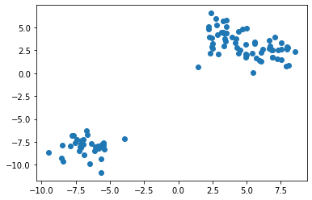

```python
# Création de données
X, y = sklearn.datasets.make_blobs(n_samples=100, centers=3, cluster_std=1)
plt.scatter(X[:, 0], X[:, 1])
```

```
[[-6.76158181 -8.03882811]
 [ 3.30419083  3.93964151]
 [ 6.67311263  2.24983855]]
```

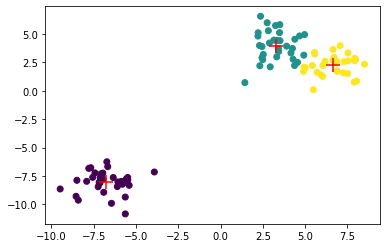

```python
# Comme toujours, on créé le model
model = KMeans(n_clusters=3)

# On l'entraine
model.fit(X, y)

# On fait nos prédictions
model.predict(X)

# Et pour le fun, visualisons :
plt.scatter(X[:, 0], X[:, 1], c=model.predict(X))
centers = model.cluster_centers_
print(centers, '\n')
plt.scatter(centers[:, 0], centers[:, 1], c='r', marker='+', s=200)
```

Maintenant si on a un nouveau point, pour savoir à quel cluster il appartient, on peut simplement étudier sa distance à un cluster.

En parlant de ça, regardons la fonctions cout, Inertia, de notre model (donc la distance moyenne) :

```python
model.inertia_
```

```
209.49027114497588
```

On pourrait maintenant utiliser les centroids en tant que transformer dans une pipeline. Mais nous n'allons pas nous y attarder.

Enfin, dernière question intéressante, comment trouver le bon nombre de clusters ? Et bien on peut utiliser la méthode Elbow :

```python
inertia = []

k_range = range(1, 10)
for k in k_range:
    model = KMeans(n_clusters=k).fit(X, y)
    inertia.append(model.inertia_)
```

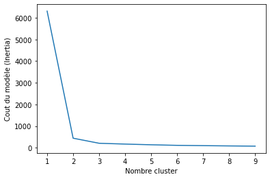

```python
plt.plot(k_range, inertia)
plt.xlabel('Nombre cluster')
plt.ylabel('Cout du modèle (Inertia)')
```

Ici on voit bien que l'on a un jolie coude et qu'il n'est pas utile d'ajouter plus de cluster que ce que nous avons set actuellement.

Il y a évidemment d'autres algorithmes de clustering comme **Agglomerative Clustering** ou encore **DBSCAN** plus spécialisés avec certains types de dataset. Ce qu'il faut retenir c'est que:

- **K-Means** est parfait quand on a des groupes assez uniformes et non-convexes (qui font des beau ronds)
- **Agglomerative Clustering** est parfait quand on a un cluster très large (beaucoup de variance)
- **DBScan** est puissant quand on a des clusters avec des formes plus variés

Généralement les données sont réparties selon une normale donc K-Means est le plus courant.

### 8.3. Detection d'anomalie

Le principe est simple, on va chercher un échantillon loin du reste. On peut étudier la probabilité d'existance d'un échantillon selon la normale des du dataset. Si on est en dessous d'un seuil, alors on le considère comme anomalie.

Une autre technique est l'**Isolation Forest**, le principe est simple, on va couper selon un x notre jeu d'échantillon, et si très vite on arrive à isoler une donnée, alors il est fort probable qu'elle soit une anomalie.

Effectivement, il y a un risque d'isoler un mauvais candidat. Cependant, cela est extrêmement peu probable. Mais pour éviter cela, on va répeter l'algo plusieurs fois. Ainsi, si un même cnadidat ressort plusieurs fois, on sera en droit de penser qu'il s'agit d'une anomalie:

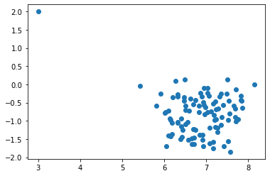

```python
X, y = sklearn.datasets.make_blobs(n_samples=100, centers=1, cluster_std=.5)
X[-1, :] = np.array([3,2])
plt.scatter(X[:, 0], X[:, 1])
```

```python
from sklearn.ensemble import IsolationForest
```

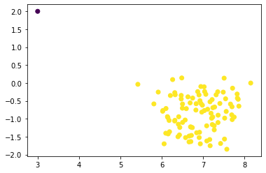

```python
model = IsolationForest(contamination=.01)  # Taux de contamination à filtrer : 1%
model.fit(X)

plt.scatter(X[:, 0], X[:, 1], c=model.predict(X))
```

Donc voilà, l'anomalie a était detectée. Cela peut permettre de detecter une activité anormale, un outlier dans un dataset... Tentons celà avec la décontamination du dataset Digits:

```python
from sklearn.datasets import load_digits
```

```python
digits = load_digits()

images = digits.images
X = digits.data
y = digits.target

print(X.shape)
```

```
(1797, 64)
```

On a 1797 images dans le dataset, écritent sur des images carrées de 64 pixels. Analysons l'une d'elle :

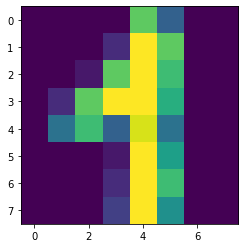

```python
plt.imshow(images[42])
```

```python
model = IsolationForest(random_state=0, contamination=.02)
```

```python
model.fit(X)
```

```
IsolationForest(contamination=0.02, random_state=0)
```

```python
# -1 correspond à des anomalies
outliers = model.predict(X) == -1
outliers
```

```
array([False, False, False, ..., False, False, False])
```

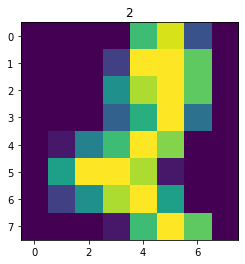

```python
# Allons chercher le première image non reconnue
i = 0
plt.imshow(images[outliers][i])
plt.title(y[outliers][i])

plt.show()
```

Qu'est ce que cette ... chose ?... Apparemment c'est un 2... Effectivement c'est un outliers tant il est étrange !

Avant de passer à la suite, mentionons la **Novelty Detection**. Là où l'Outlier Detection (Isolation Forest) cherche des anomalies dans le dataset actuel, le Novelty Detection en cherche dans les données futures, donc dans le test set.

### 8.4. Réduction de dimensions

Le but est simple réduire le nombre de dimensions d'un problème et donc sa complexité, pour accélérer le modèle et éviter l'overfitting.

L'un des algo les plus courant est l'**analyse en composantes principales**. Le but est simple, on va projeter les données sur un axe (composante principale) en cherchant à minimiser la distance entre les points et leur projection. On va donc réduire le dataset et garder au mieux la variance:

1. On calcul la matrice de covariance
2. On calcul les vecteurs propres de la matrice
3. On projette les données sur ces vecteurs (ces axes)

Don't worry, Scikit l'a déjà implémenté ! On a juste a préciser le nombre de components que l'on souhaite... Mais combien on en souhaite !? C'est assez simple :

- Si on souhaite les voir (en 2D / en 3D) alors on voudra 2 ou 3 composantes
- Si on souhaite juste accélérer le modèle, alors on va réduire au maximum le nombre de composantes, tout en cherchant à garder au moins 95 à 99% de la variance des données (donc en gardant le maximum de précision)

```python
from sklearn.decomposition import PCA
```

```
(1797, 64)
(1797, 2)
```

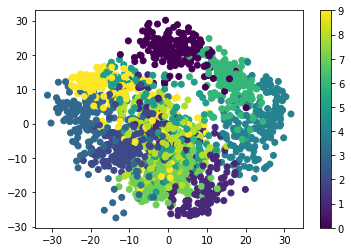

```python
print(X.shape)

model = PCA(n_components=2)
reduced = model.fit_transform(X)

print(reduced.shape, '\n')

plt.scatter(reduced[:, 0], reduced[:, 1], c=y)
plt.colorbar()
plt.show()
```

N'est-ce pas beau ? On est passé de 64 pixels à 2 dimensions et on peut donc visualiser les chiffres (color bar) par rapport à ces 2 dimensions !

Maintenant, cherchons à ne pas trop réduire la variance :

```python
# On recommence donc :
model = PCA(n_components=64)
reduced = model.fit_transform(X)
```

```python
# On regarde le pourcentage de variance préservé par chaque composante :
var_cumsum = np.cumsum(model.explained_variance_ratio_)
var_cumsum
```

```
array([0.14890594, 0.28509365, 0.40303959, 0.48713938, 0.54496353,
       0.59413263, 0.6372925 , 0.67390623, 0.70743871, 0.73822677,
       0.76195018, 0.78467714, 0.80289578, 0.82063433, 0.83530534,
       0.84940249, 0.86258838, 0.87506976, 0.88524694, 0.89430312,
       0.9031985 , 0.91116973, 0.91884467, 0.9260737 , 0.93303259,
       0.9389934 , 0.94474955, 0.94990113, 0.95479652, 0.9590854 ,
       0.96282146, 0.96635421, 0.96972105, 0.97300135, 0.97608455,
       0.97902234, 0.98158823, 0.98386565, 0.98608843, 0.98820273,
       0.99010182, 0.99168835, 0.99319995, 0.99460574, 0.99577196,
       0.99684689, 0.99781094, 0.99858557, 0.99914278, 0.99954711,
       0.99975703, 0.99983951, 0.99989203, 0.99994255, 0.99997555,
       0.99998798, 0.99999503, 0.99999804, 0.99999911, 0.99999966,
       1.        , 1.        , 1.        , 1.        ])
```

```
Argument pour garder une variance:
- supérieure à 99% : 40
- supérieure à 95% : 28
```

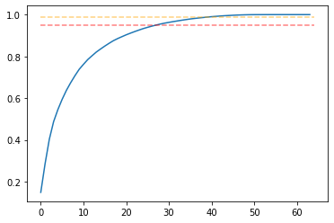

```python
# Et on ne va garder que jusque .99 ou .95 (au choix)
print('Argument pour garder une variance:')
print('- supérieure à 99% :', np.argmax(var_cumsum > .99))
print('- supérieure à 95% :',np.argmax(var_cumsum > .95))

plt.plot(var_cumsum)
plt.plot([0, 64], [.99, .99], alpha=.5, ls='--', c='orange')
plt.plot([0, 64], [.95, .95], alpha=.5, ls='--', c='red')
```

```python
# On peut donc réentrainer notre modèle avec entre 40 et 28 dimensions :
model = PCA(n_components=40)
X_reduced = model.fit_transform(X)
```

```python
# Pour retrouver les images, on va utiliser comme toujours inverse_transform :
X_recovered = model.inverse_transform(X_reduced)
```

Cependant attention, ici on ne va pas redonner la position exacte, mais la position qui avait été calculée. Donc X_recovered n'est pas exactement égal à X (bien que très proche !).

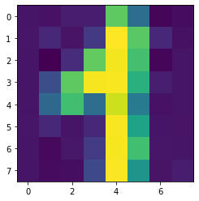

```python
# On reshape l'image en 8x8 pixels et on l'affiche :
plt.imshow(X_recovered[42].reshape((8, 8)))
```

```
Nombre de composantes nécessaires : 29
```

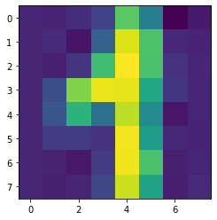

```python
# D'ailleurs on peut aussi set le taux de variance à préserver que l'on souhaite :
model = PCA(n_components=.95)
X_reduced = model.fit_transform(X)

print('Nombre de composantes nécessaires :', model.n_components_)

X_recovered = model.inverse_transform(X_reduced)

plt.imshow(X_recovered[42].reshape((8, 8)))
```

Attention cependant :

- Il faut TOUJOURS standardiser les données avant d'utiliser PCA. En effet, sachant qu'il par de l'origine, si les data ne sont pas standardisées, les performances pourront être vraiment terribles.
- Il FAUT des variables linéaires. Si c'est non linéaire (comme Cosinus / Sinus), on préfèrera utiliser le Manifold Learning (IsoMap, T-SNE)
- Il faut plutot des variables continues

Back to top

## 9. Ensemble Learning

L'ensemble learning consiste à entrainer plusieurs modèles et a analyser leurs résultats combinés pour améliorer la performance générale. C'est finalement de l'intelligence collective des IAs, ou encore la loi des grands nombre pour les stats. Le but ici n'est donc pas d'avoir un modèle très précis, mais plein de modèles rapides qui enesemble sont puissant.

Cependant pour que cela fonctionne:

- **Nombreux** : Évidemment, c'est le but, il faut combiner les intelligences individuelles pour avoir une intelligence collective, donc beaucoup de modèles.
- **Compétence** : Il faut impérativement plus de 50% de performance. Sinon on aura l'effet inverse, ça va converger vers que de mauvaises prédictions... Aie...
- **Diversité** : Il faut que chaque modèle soit différent d'une autre. Si on a plusieurs fois exactement le même modèle, on aura plusieurs fois la même prédiction donc pas d'intelligence des foules...

Nous verrons 3 type techniques :

- Le Bagging : prendre des parties aléatoires (**Bootstraping**) d'un dataset et entrainer chacune des copies d'un modèle sur une des parties du dataset. Chaque modèle est fort et entrainé (en overfitting) en parallèle des autres. L'algorithme le plus connus est la random forest.
- Le Boosting : entrainer plusieurs modèles relativement faible à corriger les erreurs de prédiction du prédécesseur. Chaque modèle est faible et entrainé (en underfitting) en série. On peut utiliser l'Ada Boosting ou le Gradient Boosting pour réaliser cela.
- Le Stacking : entrainer plusieurs modèles en parallèle, puis ajouter un dernier modèle qui va analyser le résultat de l'ensemble.

### 9.1 Voting

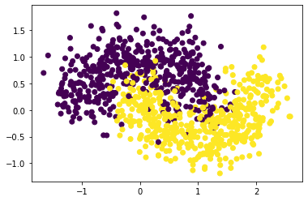

```python
X, y = sklearn.datasets.make_moons(n_samples=1000, noise=.3)
plt.scatter(X[:, 0], X[:, 1], c=y)
```

```python
X_train, X_test, y_train, y_test = train_test_split(X, y, test_size=.2)
```

Commençons avec le voting classifier !

Pour les techniques de vote, si l'on a un regressor, alors on fera la moyenne. Si l'on a un classifier, alors on a deux possibilités :

- Hard voting : vote sur les prédictions (interrogation de manière égale sur le résultat, sans prendre en compte la certitude du modèle)
- Soft voting : vote sur les probabilités de chaque classe (intéressant quand un modèle est sûr de son choix, son vote aura plus de poids), généralement jugé meilleur quand on peut l'utiliser (nécessite d'avoir accès aux proba)

Par exemple :

- Prédictions
  - Modèle A : prédit tortue à 95%
  - Modèle B : prédit aigle à 55%
  - Modèle C : prédit aigle à 60%
- Décision
  - Si Hard voting : 2 aigles / 1 tortue : C'est un aigle
  - Si Soft voting : 55 + 60 + 5 = 120 pour aigle / 95 + 45 + 40 = 180 pour tortue : C'est une tortue

```python
# Créons nos modèles
model_1 = sklearn.linear_model.SGDClassifier()
model_2 = sklearn.tree.DecisionTreeClassifier()
model_3 = sklearn.neighbors.KNeighborsClassifier(n_neighbors=2)

# Créons le voting classifier
model_4 = sklearn.ensemble.VotingClassifier([
    ('SGD', model_1),
    ('Tree', model_2),
    ('KNN', model_3)],
    voting='hard',  # Techniques de voting pour la classification
)

models  = (model_1, model_2, model_3, model_4)

for model in models:
    model.fit(X_train, y_train)
    print(model.__class__.__name__, model.score(X_test, y_test))
```

```
SGDClassifier 0.83
DecisionTreeClassifier 0.9
KNeighborsClassifier 0.885
VotingClassifier 0.905
```

Le résultat est pas mal mais on va manquer de diversité et on va être limités. Testons donc le Bagging !

### 9.2. Bagging

```python
# On créé le modèle
model = sklearn.ensemble.BaggingClassifier(
    base_estimator=sklearn.neighbors.KNeighborsClassifier(),
    n_estimators=100)

# On execute le bagging
model.fit(X_train, y_train)
model.score(X_test, y_test)
```

```
0.915
```

Voila le résultat est un peu meilleur. On peut aussi tester avec random forest qui fonctionne de base sur ce principe donc c'est encore plus simple :

```python
model = sklearn.ensemble.RandomForestClassifier(n_estimators=100)
model.fit(X_train, y_train)
model.score(X_test, y_test)
```

```
0.945
```

En général un random forest est meilleur qu'un Bagging + KNeighbors, comme on peut le voir ici :

- Voting : 90.5%
- Bagging : 91.5%
- Random Forest : 94.5%

### 9.3. Boosting

```python
model = sklearn.ensemble.AdaBoostClassifier(n_estimators=100)
model.fit(X_train, y_train)
model.score(X_test, y_test)
```

```
0.915
```

```python
model = sklearn.ensemble.GradientBoostingClassifier(n_estimators=100)
model.fit(X_train, y_train)
model.score(X_test, y_test)
```

```
0.935
```

Encore une fois on a de très bonnes prédiction :

- AdaBoost : 91.5%
- Gradient Boosting : 93.5%

Petit note d'ailleurs, si on veux tester rapidement les différents hyper paramètre pour le Bagging et Boosting, le mieux est de faire une grille comme on l'a vu précédemment.

### 9.4. Stacking

```python
# Assez semblable au voting mais avec un estimateur final à la fin
model = sklearn.ensemble.StackingClassifier([
    ('SGD', model_1),
    ('Tree', model_2),
    ('KNN', model_3)],
    final_estimator=sklearn.neighbors.KNeighborsClassifier()
)
model.fit(X_train, y_train)
model.score(X_test, y_test)
```

```
0.915
```

Back to top

Thibault **Santonja**

2021